# Exploration of National Climatic Data Center Storm Events Data

JL

02/09/2021

# Synopsis

Storms and other severe weather events can cause both public health and economic problems for communities and municipalities. Many severe events can result in fatalities, injuries, and property damage, and preventing such outcomes to the extent possible is a key concern.

Here we take the combined data from 1950 through to November 2011 and explore the most destructive weather events in terms of both public harm and economic harm. Also, we explore the same considerations on a State-by-state basis. Three visuals are produced to convey these findings. The data and code to produce the same visuals and conclusions is included in this report.

```r
library(tidyverse)
```

```r
library(ggplot2)
library(ggthemes)
library(stringi)
```

# Loading and Processing the Raw Data

This project involves exploring the U.S. National Oceanic and Atmospheric Administration’s (NOAA) storm database. This database tracks characteristics of major storms and weather events in the United States, including when and where they occur, as well as estimates of any fatalities, injuries, and property damage.

```r
# Download data
download.file("https://d396qusza40orc.cloudfront.net/repdata%2Fdata%2FStormData.csv.bz2", "rawdata.csv.bz2")

# Download documentation for data
download.file("https://d396qusza40orc.cloudfront.net/repdata%2Fpeer2_doc%2Fpd01016005curr.pdf", "rawdata_documentation.pdf", mode = "wb")

# import data into dataframe
raw <- read.csv("rawdata.csv.bz2")
```

The events in the database start in the year 1950 and end in November 2011. In the earlier years of the database there are generally fewer events recorded, most likely due to a lack of good records. More recent years should be considered more complete.

## The Data

The dataframe `raw` has 37 columns and 900,000+ observations across the united states. Here is a brief overview.

```r
str(raw)
```

```
## 'data.frame':    902297 obs. of  37 variables:
##  $ STATE__   : num  1 1 1 1 1 1 1 1 1 1 ...
##  $ BGN_DATE  : chr  "4/18/1950 0:00:00" "4/18/1950 0:00:00" "2/20/1951 0:00:00" "6/8/1951 0:00:00" ...
##  $ BGN_TIME  : chr  "0130" "0145" "1600" "0900" ...
##  $ TIME_ZONE : chr  "CST" "CST" "CST" "CST" ...
##  $ COUNTY    : num  97 3 57 89 43 77 9 123 125 57 ...
##  $ COUNTYNAME: chr  "MOBILE" "BALDWIN" "FAYETTE" "MADISON" ...
##  $ STATE     : chr  "AL" "AL" "AL" "AL" ...
##  $ EVTYPE    : chr  "TORNADO" "TORNADO" "TORNADO" "TORNADO" ...
##  $ BGN_RANGE : num  0 0 0 0 0 0 0 0 0 0 ...
##  $ BGN_AZI   : chr  "" "" "" "" ...
##  $ BGN_LOCATI: chr  "" "" "" "" ...
##  $ END_DATE  : chr  "" "" "" "" ...
##  $ END_TIME  : chr  "" "" "" "" ...
##  $ COUNTY_END: num  0 0 0 0 0 0 0 0 0 0 ...
```

[output cut: 23 more lines]

Information that we will explore are

- Location: STATE_, COUNTY, COUNTYNAME, STATE
- Time: BGN_DATE, BGN_TIME
- Event Information: EVTYPE, LENGTH, WIDTH, F, REMARKS
- Damage: FATALITIES, INJURIES, PROPDMG, PROPDMGEXP, CROPDMG, CROPDMGEXP

For LENGTH and WIDTH, this is the path length (in miles and tenths of miles) and maximum path width (in yards) for all tornadoes.

For F, The “Saffir-Simpson Hurricane and Tropical Cyclone Scale” is used

1. Windspeed 64-82 kts (74-95 mph), storm tide: 4-5 FT, Damage: Minor
2. Windspeed 83-95 kts (96-110 mph), storm tide: 6-8 FT, Damage: Moderate
3. Windspeed 96-113 kts (111-130 mph), storm tide: 9-12 FT, Damage: Major
4. Windspeed 114-135 kts (131-155 mph), storm tide: 13-18 FT, Damage: Severe
5. Windspeed >135 kts (>155 mph), storm tide: >18 FT, Damage: Catastrophic

For REMARKS, this is a description of the event.

For PROPDMGEXP and CROPDMGEXP, characters are used to signify cost of damage and include “K” for thousands, “M” for millions, and “B” for billions.

## Processing

To process the data for analysis, we will select only the variables that we have outlined above. Further, we will rename these variables to more accessible versions and ensure they are cast into the correct type for calculations.

Secondly, we will create a dataframe for locations, containing both state and county ids with their respective state and county names, for reference.

```r
# collect location IDs for reference and remove duplicate rows
counties <- select(raw, "STATE__", "STATE", "COUNTY", "COUNTYNAME") %>%
  distinct(.keep_all = TRUE)

colnames(counties) <- c("state_id", "state_name", "county_id", "county_name")

states <- select(raw, "STATE__", "STATE") %>%
  distinct(.keep_all = TRUE)

colnames(states) <- c("state_id", "state_name")

# states contains duplicates, over separate IDs.
# Manually remove against a list of abbreviations
states <- states[-c(79, 59, 63, 57, 56, 55, 95, 94, 93, 65, 70,
                    60, 68, 61,  66, 73, 71, 72, 76, 74, 62,
                    67, 78, 77, 51, 69, 75, 53, 64, 58, 20, 8), ]


# trim raw to chosen variables
clean <- select(raw, c("STATE__", "COUNTY", "BGN_DATE", "BGN_TIME", "EVTYPE", "LENGTH", "WIDTH", "F", "REMARKS", "FATALITIES", "INJURIES", "PROPDMG", "PROPDMGEXP", "CROPDMG", "CROPDMGEXP"))

# rename columns
colnames(clean) <- c("state_id", "county_id", "start_date", "start_time", "event", "length", "width", "F", "remarks", "fatalities", "injuries", "property_damage", "property_damage_cat", "crop_damage", "crop_damage_cat")

# cast raw into correct types and formats
clean$state_id <- as.integer(clean$state_id)
clean$county_id <- as.integer(clean$county_id)

clean$event <- stri_trans_totitle(as.factor(clean$event))

clean$F <- as.factor(clean$F)

clean$start_date <- as.Date(as.character(
  strptime(clean$start_date, format = "%m/%d/%Y")))

# We want to include damage_category into damage counts.
# first swap K, M, B with 1e3, 1e6 and 1e9 respectively

clean$property_damage_cat[clean$property_damage_cat == ""] <- 1
clean$property_damage_cat[clean$property_damage_cat == "K"] <- 1e3
clean$property_damage_cat[clean$property_damage_cat == "M"] <- 1e6
clean$property_damage_cat[clean$property_damage_cat == "B"] <- 1e9

clean$crop_damage_cat[clean$crop_damage_cat == ""] <- 1
clean$crop_damage_cat[clean$crop_damage_cat == "K"] <- 1e3
clean$crop_damage_cat[clean$crop_damage_cat == "M"] <- 1e6
clean$crop_damage_cat[clean$crop_damage_cat == "B"] <- 1e9

# now multiply to get correct damage values

clean$property_damage <- as.numeric(clean$property_damage) * as.numeric(clean$property_damage_cat)
clean$crop_damage <- as.numeric(clean$crop_damage) * as.numeric(clean$crop_damage_cat)
```

# Results

## Most harmful events to people’s health

This first question we want to investigate is the following

- Across the United States, which types of events are most harmful with respect to population health?

There are a few ways to interpret this. Direct harm, is easily fatalities and injuries, however indirectly we could have the economic impact such as property damage, or crop damage. So we will limit this to the direct harm.

We will group by event and summarise the data

```r
 direct_harm <- clean %>%
  group_by(event) %>%
  summarise(number_of_events = n(),
            total_fatalities = sum(fatalities),
            total_injuries = sum(injuries),
            total_sum = sum(fatalities) + sum(injuries)) %>%
  arrange(desc(total_sum))

head(direct_harm)
```

```
## # A tibble: 6 x 5
##   event          number_of_events total_fatalities total_injuries total_sum
##   <chr>                     <int>            <dbl>          <dbl>     <dbl>
## 1 Tornado                   60652             5633          91346     96979
## 2 Excessive Heat             1678             1903           6525      8428
## 3 Tstm Wind                219942              504           6957      7461
## 4 Flood                     25327              470           6789      7259
## 5 Lightning                 15754              816           5230      6046
## 6 Heat                        767              937           2100      3037
```

From the summary above, we can see that Tornados have the most fatalities and injuries associated with them. We can also see that the most frequent event is Thunderstorm Wind (Tstm Wind).

To build a visual, we will adjust the dataframe. Trim to just the top 20 contributing events, sorted by sum of fatalities and injuries. Then collapse fatalities and injuries into one column, but associating a label with each, for ggplot to interpret.

```r
# trim a copy of dataframe to top20, select key columns
dh_short <- direct_harm[1:20, ]
dh_short2 <- dh_short

# rename two columns to merge on
colnames(dh_short)[3] <- "Incidents"
colnames(dh_short2)[4] <- "Incidents"

# select only the columns we need for a merge
dh_short <- select(dh_short, c("event", "total_sum", "Incidents"))
dh_short2 <- select(dh_short2, c("event", "total_sum", "Incidents"))

# create a label to split data on plotting
dh_short$label <- "Fatalities"
dh_short2$label <- "Injuries"

# merge dataframes, remove the temprorary second
dh_short <- rbind(dh_short, dh_short2)

rm(dh_short2)
rm(direct_harm)
```

Now we have the data we need for plotting an informational visual in a way that allows us to create it easily.

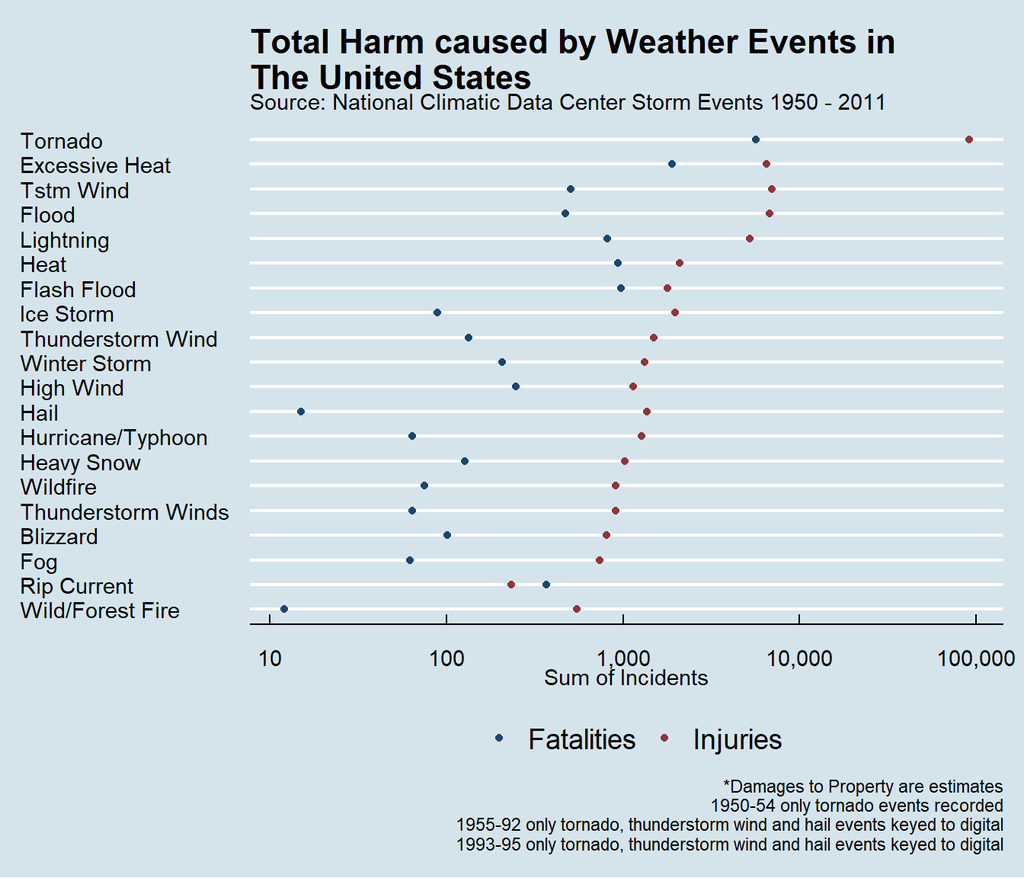

```r
# plot for the top 20 by total of fatalities and injuries
ggplot(dh_short, aes(x = Incidents,
                 y = reorder(event, total_sum),
                 colour = label),
                 size = 3) +

  theme_economist() +

  scale_colour_stata() +

  geom_point() +

  labs(x = "Sum of Incidents",
       y = NULL,
       colour = NULL,
       title = "Total Harm caused by Weather Events in\nThe United States",
       subtitle = "Source: National Climatic Data Center Storm Events 1950 - 2011",
       caption = "*Damages to Property are estimates\n1950-54 only tornado events recorded\n 1955-92 only tornado, thunderstorm wind and hail events keyed to digital\n1993-95 only tornado, thunderstorm wind and hail events keyed to digital") +

  guides(fill = guide_legend(title = NULL)) +

  theme(
    legend.position = "bottom") +

  scale_x_log10(breaks = c(1e1, 1e2, 1e3, 1e4, 1e5),
                labels = c("10", "100", "1,000", "10,000", "100,000"))
```

As you can see from the graph above, for the top 20 events, the number of injuries surpasses the number of fatalities. Which is to expected. The exception is Rip Current, which understandably is very dangerous once one has been dragged into one. The most destructive event by far in the U.S. is Tornado, with both regards to total fatalities and total injuries. The latter by a stunning degree. Tornadoes are highly destructive events and they frequent the country. At the bottom of the top 20 events is Wild/Forest Fire, which, alike Hail, show that incidents are much less likely to be fatal, however could still be quite serious.

## Most harmful events with respect to the economy

This second question we want to investigate is the following

- Across the United States, which types of events have the greatest economic consequences?

In this regard, we will investigate the effects of these weather events on damage to Property and damage to Crops. To do so we will group by events and take the sum of property damage and the sum of crop damage, then sort by the total of the two.

```r
economic_harm <- clean %>%
  group_by(event) %>%
  summarise(number_of_events = n(),
            property_damage = sum(property_damage),
            crop_damage = sum(crop_damage),
            total_damage = sum(property_damage) + sum(crop_damage)) %>%
  arrange(desc(total_damage))

head(economic_harm)
```

```
## # A tibble: 6 x 5
##   event             number_of_events property_damage crop_damage total_damage
##   <chr>                        <int>           <dbl>       <dbl>        <dbl>
## 1 Flood                        25327    144657709807  5661968450 150319678257
## 2 Hurricane/Typhoon               88     69305840000  2607872800  71913712800
## 3 Storm Surge                    261     43323536000        5000  43323541000
## 4 Drought                       2488      1046106000 13972566000  15018672000
## 5 Hurricane                      174     11868319010  2741910000  14610229010
## 6 River Flood                    173      5118945500  5029459000  10148404500
```

From the summary above we can see that Flood causes the most expensive damage, over twice the next event, Hurricane/Typhoon. The event most damaging to crops is Drought. Especially noteworthy as it causes relatively low property damage. Floods are second in crop damage, but as already mentioned, deal significant property damage also.

To build a visual, we will adjust the dataframe. Trim to just the top 20 contributing events, sorted by sum of damages. Then collapse property damages and crop damages into one column, but associating a label with each, for ggplot to interpret.

```r
# trim a copy of dataframe to top20, select key columns
eco_short <- economic_harm[1:20, ]
eco_short2 <- eco_short

# rename two columns to merge on
colnames(eco_short)[3] <- "Incidents"
colnames(eco_short2)[4] <- "Incidents"

# select only the columns we need for a merge
eco_short <- select(eco_short, c("event", "total_damage", "Incidents"))
eco_short2 <- select(eco_short2, c("event", "total_damage", "Incidents"))

# create a label to split data on plotting
eco_short$label <- "Property Damage"
eco_short2$label <- "Crop Damage"

# merge dataframes, remove the temprorary second
eco_short <- rbind(eco_short, eco_short2)

# rescale damage to thousands of dollars
eco_short$total_damage <- eco_short$total_damage

rm(eco_short2)
rm(economic_harm)
```

Now we have the data we need for plotting an informational visual in a way that allows us to create it easily.

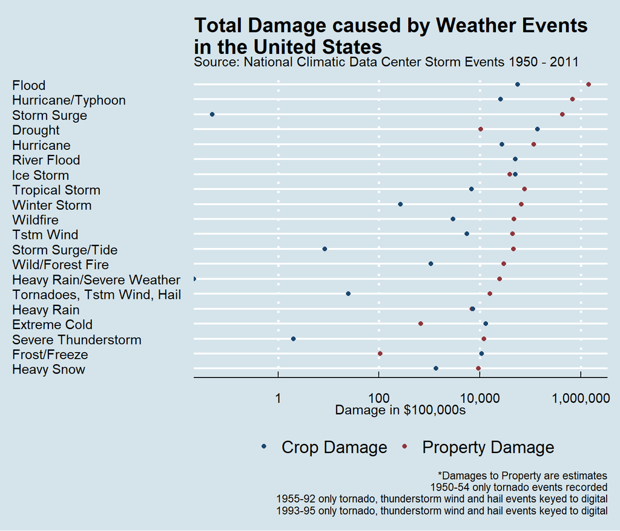

```r
# plot for the top 20 by total of fatalities and injuries
ggplot(eco_short, aes(x = Incidents,
                 y = reorder(event, total_damage),
                 colour = label),
                 size = 3) +

  theme_economist() +

  scale_colour_stata() +

  geom_point() +

  labs(x = "Damage in $100,000s",
       y = NULL,
       colour = NULL,
       title = "Total Damage caused by Weather Events\nin the United States",
       subtitle = "Source: National Climatic Data Center Storm Events 1950 - 2011",
       caption = "*Damages to Property are estimates\n1950-54 only tornado events recorded\n 1955-92 only tornado, thunderstorm wind and hail events keyed to digital\n1993-95 only tornado, thunderstorm wind and hail events keyed to digital") +

  guides(fill = guide_legend(title = NULL)) +

  theme(legend.position = "bottom",
        panel.grid.major.x = element_line(colour = "white",
                                      size = 1,
                                      linetype = "dotted")) +

  scale_x_log10(breaks = c(1e5, 1e7, 1e9, 1e11),
                labels = c("1", "100", "10,000", "1,000,000"))
```

## State that suffers the most

As we have the data that allows us to investigate down to the state level, we will. We will use the same steps as before, yet grouping by state and aggregating for each of what we have explored already. We’ll sort by the number of events in this case.

```r
state_harm <- clean %>%
  group_by(state_id) %>%
  summarise(number_of_events = n(),
            damage = (sum(property_damage, na.rm=TRUE) + sum(crop_damage, na.rm=TRUE))/1e4,
            fatalities = sum(fatalities),
            injuries = sum(injuries)) %>%
  arrange(desc(number_of_events))

state_harm <- merge(state_harm, states)

head(state_harm)
```

```
##   state_id number_of_events      damage fatalities injuries state_name
## 1        1            22739  1781823.11        784     8742         AL
## 2        2             4390    29790.63         74      112         AK
## 3        4             6156   396053.07        208      968         AZ
## 4        5            27102   455709.64        530     5550         AR
## 5        6            10780 12711585.94        550     3278         CA
## 6        8            20473   288994.99        163     1004         CO
```

From the summary above we can see that there is a great range of values across the United States. Undoubtedly, size of state and population are strong factors in here, However, it is not unreasonable to assume that both location and government management of prevention and preparation play a significant role also.

To build a visual, we will adjust the dataframe. Collapse number of events, damages, fatalities and injuries into one column, but associating a label with each, for ggplot to interpret.

```r
# copies of dataframe to merge
state_n <- state_harm
state_p <- state_harm
state_f <- state_harm
state_i <- state_harm

# rename two columns to merge on
state_n$values <- state_n$number_of_events
colnames(state_p)[3] <- "values"
colnames(state_f)[4] <- "values"
colnames(state_i)[5] <- "values"

# create a label to split data on plotting
state_n$label <- "Number of Events"
state_p$label <- "Damages $10,000s"
state_f$label <- "Fatalities"
state_i$label <- "Injuries"

# select only the columns we need for a merge
state_n <- state_n %>% select(c("state_name", "values", "label", "number_of_events"))
state_p <- state_p %>% select(c("state_name", "values", "label", "number_of_events"))
state_f <- state_f %>% select(c("state_name", "values", "label", "number_of_events"))
state_i <- state_i %>% select(c("state_name", "values", "label", "number_of_events"))


# merge dataframes, remove the temprorary dataframes
state_n <- rbind(state_n, state_p)
state_n <- rbind(state_n, state_f)
state_n <- rbind(state_n, state_i)

state_harm <- state_n

# sorting
arrange(state_harm, desc(number_of_events));
```

```
##     state_name      values            label number_of_events
## 1           TX    83728.00 Number of Events            83728
## 2           TX  3394243.80 Damages $10,000s            83728
## 3           TX     1366.00       Fatalities            83728
## 4           TX    17667.00         Injuries            83728
## 5           KS    53441.00 Number of Events            53441
## 6           KS   505472.03 Damages $10,000s            53441
## 7           KS      356.00       Fatalities            53441
## 8           KS     3449.00         Injuries            53441
## 9           OK    46802.00 Number of Events            46802
## 10          OK   671968.71 Damages $10,000s            46802
## 11          OK      458.00       Fatalities            46802
## 12          OK     5710.00         Injuries            46802
## 13          MO    35648.00 Number of Events            35648
## 14          MO   793182.72 Damages $10,000s            35648
```

[output cut: 186 more lines]

```r
# remove temporary dataframes
rm(state_n, state_p, state_f, state_i)

head(state_harm)
```

```
##   state_name values            label number_of_events
## 1         AL  22739 Number of Events            22739
## 2         AK   4390 Number of Events             4390
## 3         AZ   6156 Number of Events             6156
## 4         AR  27102 Number of Events            27102
## 5         CA  10780 Number of Events            10780
## 6         CO  20473 Number of Events            20473
```

Now we have the data we need for plotting an informational visual in a way that allows us to create it easily.

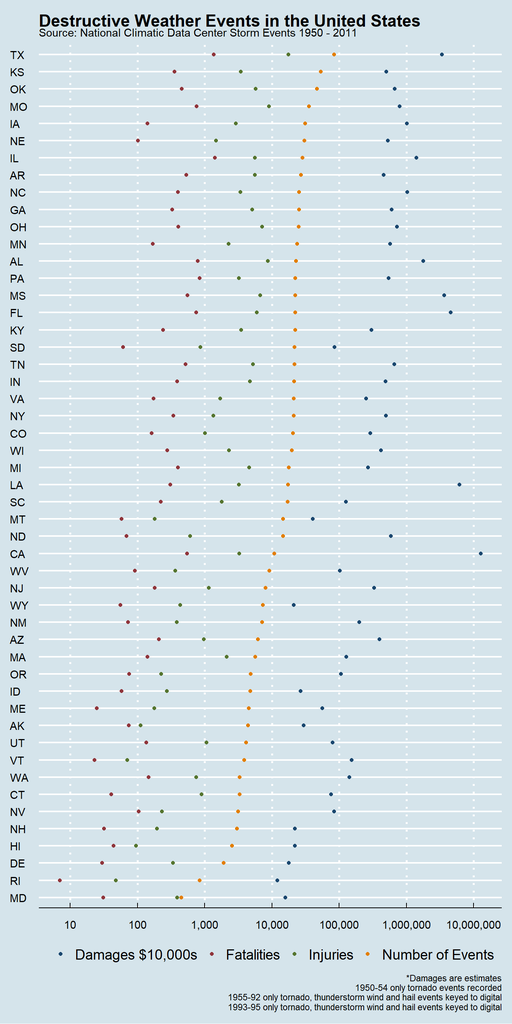

```r
# plot for the top 20 by total of fatalities and injuries
ggplot(state_harm, aes(x = values,
                 y = reorder(state_name, number_of_events),
                 colour = label),
                 size = 3, shape = 22) +

  theme_economist() +

  scale_colour_stata() +

  geom_point() +

  labs(x = NULL,
       y = NULL,
       colour = NULL,
       title = "Destructive Weather Events in the United States",
       subtitle = "Source: National Climatic Data Center Storm Events 1950 - 2011",
       caption = "*Damages are estimates\n1950-54 only tornado events recorded\n 1955-92 only tornado, thunderstorm wind and hail events keyed to digital\n1993-95 only tornado, thunderstorm wind and hail events keyed to digital") +

  guides(fill = guide_legend(title = NULL)) +

  scale_fill_discrete(labels = c("Fatalities",
                                 "Injuries",
                                 "Events",
                                 "Damages $10,000s")) +

  theme(
    legend.position = "bottom",
    panel.grid.major.x = element_line(colour = "white",
                                      size = 1,
                                      linetype = "dotted")) +

  scale_x_log10(breaks = c(1e1, 1e2, 1e3, 1e4, 1e5, 1e6, 1e7),
                labels = c("10", "100", "1,000","10,000", "100,000", "1,000,000", "10,000,000"))
```

From this visual, we can see that a strong association between the number of events and all other variables. Which is completely expected. California has had the most damages overall, we know that several droughts have been very costly. However it is Illinois and Texas (in that order) where most fatalities have occurred due to weather. Illinois has a history of Tornados, notably the [Tri-State Torndao](https://en.wikipedia.org/wiki/Tri-State_Tornado). Texas has a very variable climate and also suffers Hurricanes and Tornados and other [storms](https://en.wikipedia.org/wiki/Texas#Storms). Naturally, this contributes to the high level of injuries in Texas. The “safest” states then are Rhode Island and Maryland. Interestingly, for Maryland, it suggests that with almost as many injuries as number of events, that makes it almost one person injured for each event. Though, there are fewer fatalities and injuries due to weather in Rhode Island, making it the “safest state for bad weather”.